# Power simulation for a RI-CLPM

Prof. Thomas Pollet, Northumbria University, UK

2025-07-30

# Background

A paper I reviewed conducted an RI-CLPM, I wanted to verify the proposed sample size for 80% power. The authors proposed *n* = 400. I thought I would share the code, in case anybody wanted to have a go at a power analysis for RI-CLPM.

# Packages

```r
library("powRICLPM")
library("tidyverse")
```

```r
library("future")
library("furrr")
library("progressr")
library("ggplot2")
library("ggthemes")
library("wesanderson")
library("grateful")
library("papaja")
future::plan(multisession)
```

# Simulation.

## Setup

Values from Manual.

```r
Phi <- matrix(c(.4, .1, .15, .3), ncol = 2, byrow = TRUE)
```

```r
check_Phi(Phi)
```

```
## According to this `Phi`, the lagged effects are:
## • Autoregressive effect of A: 0.4
## • Autoregressive effect of B: 0.3
## • Cross-lagged effect of A -> B: 0.15
## • Cross-lagged effect of B -> A: 0.1
```

Below uses reasonable starting values from the [manual](https://jeroendmulder.github.io/powRICLPM/articles/start.html).

However, I changed a key path of interest, this is .15 (A on B). (Authors proposed *r* = .15)

Number of reps is perhaps smallish (but I boosted it from example), you might want to boost it to 10k but for our purpose 1,000 seems sufficient. Note that this takes some time.

I have hidden the warnings error as `lavaan` will print various warnings for individual models.

```r
out_preliminary <- powRICLPM(target_power = 0.8,search_lower = 200, search_upper = 1000, search_step = 50, time_points = c(3, 4, 5), ICC = c(0.3, 0.5, 0.7), RI_cor = 0.3, Phi = Phi, within_cor = 0.3, reps = 1000, seed = 1234567)
```

## Output

```r
summary(out_preliminary)
```

```
## powRICLPM (0.2.1) simulated power for 153 experimental conditions.
##
##
## Table: SUMMARY OF ANALYSIS PER EXPERIMENTAL CONDITION
##
##  Sample size   Time points   ICC   Reliability   Error   Not converged   Inadmissible
## ------------  ------------  ----  ------------  ------  --------------  -------------
##          200             3   0.3             1       0               4            177
##          250             3   0.3             1       0               6            135
##          300             3   0.3             1       0               3             88
##          350             3   0.3             1       0               5             50
##          400             3   0.3             1       0               3             58
##          450             3   0.3             1       0               4             47
##          500             3   0.3             1       0               3             27
##          550             3   0.3             1       0               6             16
```

[output cut: 145 more lines]

A on B –> .15

The graph could be further beautified, but I have left it here. And perhaps Tufte’s theme is not ideal.

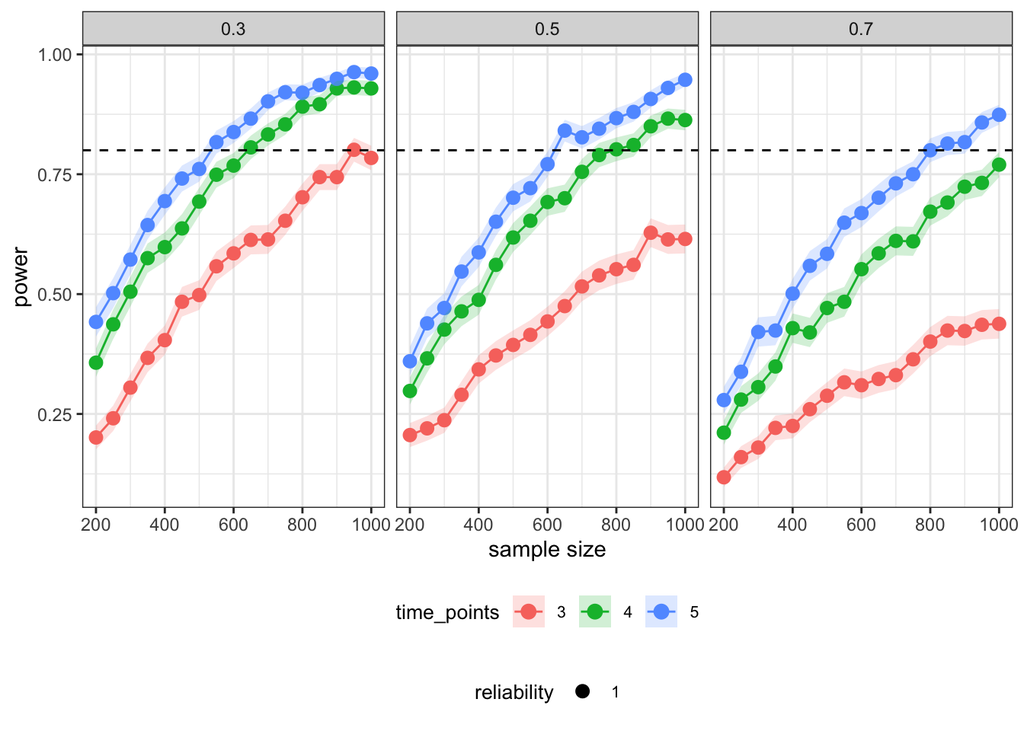

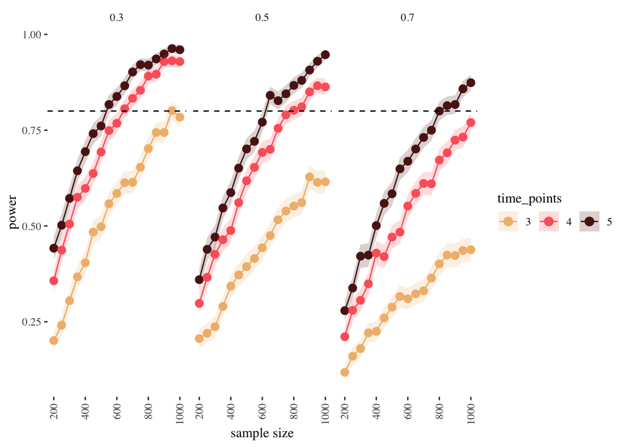

```r
plot(out_preliminary, parameter = "wB2~wA1") + theme_tufte() + theme(axis.text.x = element_text(angle = 90, vjust = 0.5, hjust=1))  +
  scale_color_manual(values = wes_palette("GrandBudapest1")) + scale_fill_manual(values = wes_palette("GrandBudapest1")) + guides(shape = "none")
```

This is a weaker effect.

B on A –> .1

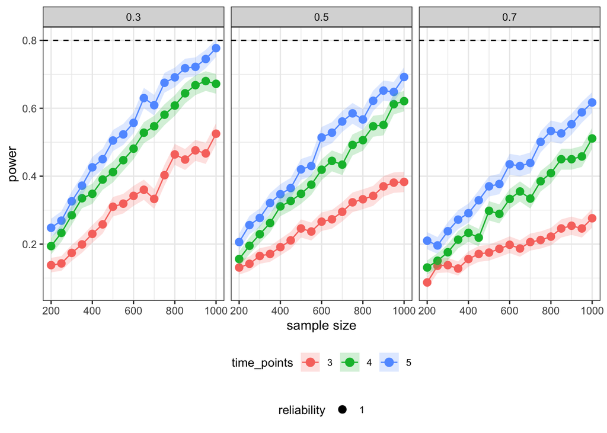

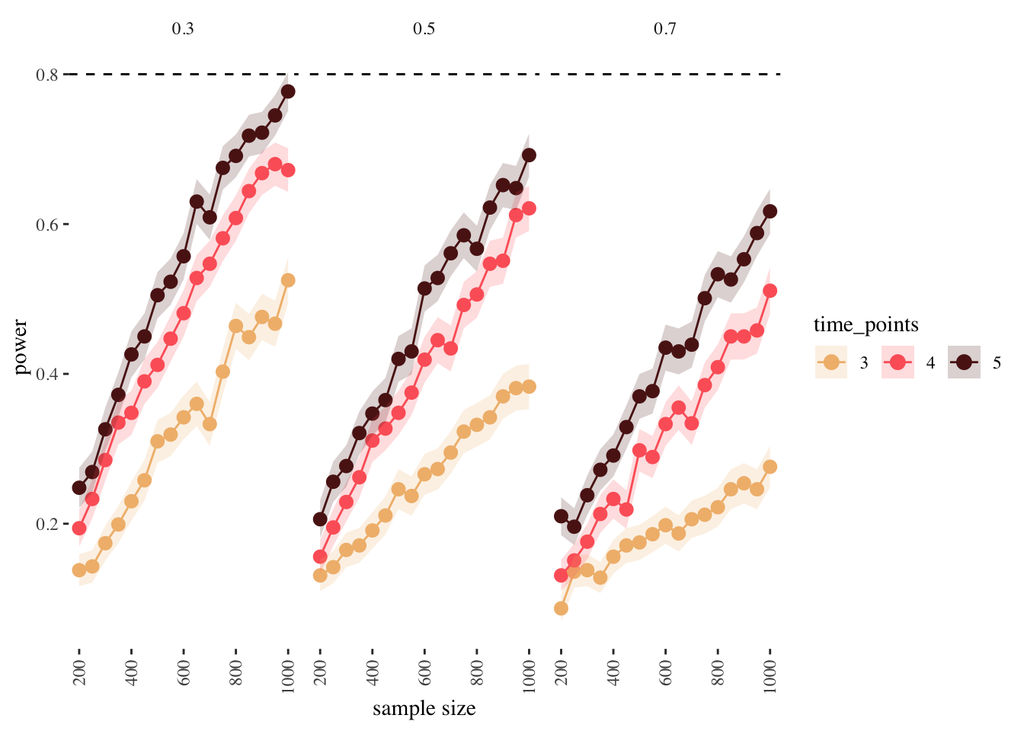

```r
plot(out_preliminary, parameter = "wA2~wB1") + theme_tufte() + theme(axis.text.x = element_text(angle = 90, vjust = 0.5, hjust=1))  +
  scale_color_manual(values = wes_palette("GrandBudapest1")) + scale_fill_manual(values = wes_palette("GrandBudapest1"))  + guides(shape = "none")
```

# Conclusion

The above simulations suggest that *n* = 400 does not seem to satisfy 80% power, under any scenario. The above code can be modified to other scenarios. Note that as described by the package author, there are assumptions made (e.g., Multivariate normality, etc) – see the paper by [Mulder (2022)](https://doi.org/10.1080/10705511.2022.2122467). So, a broader range of scenarios might need to be explored for a particular design.

# Package citations

```r
r_refs(file = "r-analysis-references.bib")
my_citation <- cite_r(file = "r-analysis-references.bib")
```

R (Version 4.4.2; R Core Team 2024) and the R-packages *dplyr* (Version 1.1.4; Wickham et al. 2023), *forcats* (Version 1.0.0; Wickham 2023a), *furrr* (Version 0.3.1; Vaughan and Dancho 2022), *ggplot2* (Version 3.5.2; Wickham 2016), *ggthemes* (Version 5.1.0; Arnold 2024), *grateful* (Version 0.2.10; Rodriguez-Sanchez and Jackson 2023), *lubridate* (Version 1.9.3; Grolemund and Wickham 2011), *papaja* (Version 0.1.3; Aust and Barth 2024), *powRICLPM* (Version 0.2.1; Jeroen D. Mulder 2022), *progressr* (Version 0.15.1; Bengtsson 2024), *purrr* (Version 1.0.4; Wickham and Henry 2025), *readr* (Version 2.1.5; Wickham, Hester, and Bryan 2024), *RJ-2021-048* (Bengtsson 2021, 2021, 2021, 2021, 2021, 2021), *stringr* (Version 1.5.1; Wickham 2023b), *tibble* (Version 3.3.0; Müller and Wickham 2025), *tidyr* (Version 1.3.1; Wickham, Vaughan, and Girlich 2024), *tidyverse* (Version 2.0.0; Wickham et al. 2019), *tinylabels* (Version 0.2.5; Barth 2025), and *wesanderson* (Version 0.3.7; Ram and Wickham 2023)

# References

Arnold, Jeffrey B. 2024. *Ggthemes: Extra Themes, Scales and Geoms for ’Ggplot2’*. https://CRAN.R-project.org/package=ggthemes.

Aust, Frederik, and Marius Barth. 2024. *papaja: Prepare Reproducible APA Journal Articles with R Markdown*. https://doi.org/10.32614/CRAN.package.papaja.

Barth, Marius. 2025. *tinylabels: Lightweight Variable Labels*. https://doi.org/10.32614/CRAN.package.tinylabels.

Bengtsson, Henrik. 2021. “A Unifying Framework for Parallel and Distributed Processing in r Using Futures.” *The R Journal* 13 (2): 208–27. https://doi.org/10.32614/RJ-2021-048.

———. 2024. *Progressr: An Inclusive, Unifying API for Progress Updates*. https://CRAN.R-project.org/package=progressr.

Grolemund, Garrett, and Hadley Wickham. 2011. “Dates and Times Made Easy with lubridate.” *Journal of Statistical Software* 40 (3): 1–25. https://www.jstatsoft.org/v40/i03/.

Jeroen D. Mulder. 2022. “Power Analysis for the Random Intercept Cross-Lagged Panel Model Using the powRICLPM r-Package.” *Structural Equation Modeling: A Multidisciplinary Journal*. https://doi.org/10.1080/10705511.2022.2122467.

Müller, Kirill, and Hadley Wickham. 2025. *Tibble: Simple Data Frames*. https://CRAN.R-project.org/package=tibble.

R Core Team. 2024. *R: A Language and Environment for Statistical Computing*. Vienna, Austria: R Foundation for Statistical Computing. https://www.R-project.org/.

Ram, Karthik, and Hadley Wickham. 2023. *Wesanderson: A Wes Anderson Palette Generator*. https://CRAN.R-project.org/package=wesanderson.

Rodriguez-Sanchez, Francisco, and Connor P. Jackson. 2023. *Grateful: Facilitate Citation of r Packages*. https://pakillo.github.io/grateful/.

Vaughan, Davis, and Matt Dancho. 2022. *Furrr: Apply Mapping Functions in Parallel Using Futures*. https://CRAN.R-project.org/package=furrr.

Wickham, Hadley. 2016. *Ggplot2: Elegant Graphics for Data Analysis*. Springer-Verlag New York. https://ggplot2.tidyverse.org.

———. 2023a. *Forcats: Tools for Working with Categorical Variables (Factors)*. https://CRAN.R-project.org/package=forcats.

———. 2023b. *Stringr: Simple, Consistent Wrappers for Common String Operations*. https://CRAN.R-project.org/package=stringr.

Wickham, Hadley, Mara Averick, Jennifer Bryan, Winston Chang, Lucy D’Agostino McGowan, Romain François, Garrett Grolemund, et al. 2019. “Welcome to the tidyverse.” *Journal of Open Source Software* 4 (43): 1686. https://doi.org/10.21105/joss.01686.

Wickham, Hadley, Romain François, Lionel Henry, Kirill Müller, and Davis Vaughan. 2023. *Dplyr: A Grammar of Data Manipulation*. https://CRAN.R-project.org/package=dplyr.

Wickham, Hadley, and Lionel Henry. 2025. *Purrr: Functional Programming Tools*. https://CRAN.R-project.org/package=purrr.

Wickham, Hadley, Jim Hester, and Jennifer Bryan. 2024. *Readr: Read Rectangular Text Data*. https://CRAN.R-project.org/package=readr.

Wickham, Hadley, Davis Vaughan, and Maximilian Girlich. 2024. *Tidyr: Tidy Messy Data*. https://CRAN.R-project.org/package=tidyr.